# Project Python Foundations: FoodHub Data Analysis

### Context

The number of restaurants in New York is increasing day by day. Lots of students and busy professionals rely on those restaurants due to their hectic lifestyles. Online food delivery service is a great option for them. It provides them with good food from their favorite restaurants. A food aggregator company FoodHub offers access to multiple restaurants through a single smartphone app.

The app allows the restaurants to receive a direct online order from a customer. The app assigns a delivery person from the company to pick up the order after it is confirmed by the restaurant. The delivery person then uses the map to reach the restaurant and waits for the food package. Once the food package is handed over to the delivery person, he/she confirms the pick-up in the app and travels to the customer's location to deliver the food. The delivery person confirms the drop-off in the app after delivering the food package to the customer. The customer can rate the order in the app. The food aggregator earns money by collecting a fixed margin of the delivery order from the restaurants.

### Objective

The food aggregator company has stored the data of the different orders made by the registered customers in their online portal. They want to analyze the data to get a fair idea about the demand of different restaurants which will help them in enhancing their customer experience. Suppose you are hired as a Data Scientist in this company and the Data Science team has shared some of the key questions that need to be answered. Perform the data analysis to find answers to these questions that will help the company to improve the business.

### Data Description

The data contains the different data related to a food order. The detailed data dictionary is given below.

### Data Dictionary

- order_id: Unique ID of the order
- customer_id: ID of the customer who ordered the food
- restaurant_name: Name of the restaurant
- cuisine_type: Cuisine ordered by the customer
- cost_of_the_order: Cost of the order
- day_of_the_week: Indicates whether the order is placed on a weekday or weekend (The weekday is from Monday to Friday and the weekend is Saturday and Sunday)
- rating: Rating given by the customer out of 5
- food_preparation_time: Time (in minutes) taken by the restaurant to prepare the food. This is calculated by taking the difference between the timestamps of the restaurant's order confirmation and the delivery person's pick-up confirmation.
- delivery_time: Time (in minutes) taken by the delivery person to deliver the food package. This is calculated by taking the difference between the timestamps of the delivery person's pick-up confirmation and drop-off information

### Let us start by importing the required libraries

```python
# Installing the libraries with the specified version.
!pip install numpy==1.25.2 pandas==1.5.3 matplotlib==3.7.1 seaborn==0.13.1 -q --user
```

**Note**: *After running the above cell, kindly restart the notebook kernel and run all cells sequentially from the start again.*

```python
# import libraries for data manipulation
import numpy as np
import pandas as pd

# import libraries for data visualization
import matplotlib.pyplot as plt
import seaborn as sns
```

### Understanding the structure of the data

```python
# uncomment and run the following lines for Google Colab
from google.colab import drive
drive.mount('/content/drive')
```

```python
# Write your code here to read the data
df=pd.read_csv('/content/drive/MyDrive/Colab Notebooks/FoodHubProject/foodhub_order.csv')
```

```python
# Write your code here to view the first 5 rows
df.head()
```

|  | order_id | customer_id | restaurant_name | cuisine_type | cost_of_the_order | day_of_the_week | rating | food_preparation_time | delivery_time |
| --- | --- | --- | --- | --- | --- | --- | --- | --- | --- |
| 0 | 1477147 | 337525 | Hangawi | Korean | 30.75 | Weekend | Not given | 25 | 20 |
| 1 | 1477685 | 358141 | Blue Ribbon Sushi Izakaya | Japanese | 12.08 | Weekend | Not given | 25 | 23 |
| 2 | 1477070 | 66393 | Cafe Habana | Mexican | 12.23 | Weekday | 5 | 23 | 28 |
| 3 | 1477334 | 106968 | Blue Ribbon Fried Chicken | American | 29.20 | Weekend | 3 | 25 | 15 |
| 4 | 1478249 | 76942 | Dirty Bird to Go | American | 11.59 | Weekday | 4 | 25 | 24 |

### **Question 1:** How many rows and columns are present in the data? [0.5 mark]

```python
# Write your code here
print("Rows",df.shape[0])
print("Columns",df.shape[1])
```

```
Rows 1898
Columns 9
```

#### Observations:

The dataset contains 1898 rows and 9 columns.

### **Question 2:** What are the datatypes of the different columns in the dataset? (The info() function can be used) [0.5 mark]

```python
# Write your code here
df.info()
```

```
<class 'pandas.core.frame.DataFrame'>
RangeIndex: 1898 entries, 0 to 1897
Data columns (total 9 columns):
 #   Column                 Non-Null Count  Dtype
---  ------                 --------------  -----
 0   order_id               1898 non-null   int64
 1   customer_id            1898 non-null   int64
 2   restaurant_name        1898 non-null   object
 3   cuisine_type           1898 non-null   object
 4   cost_of_the_order      1898 non-null   float64
 5   day_of_the_week        1898 non-null   object
 6   rating                 1898 non-null   object
 7   food_preparation_time  1898 non-null   int64
 8   delivery_time          1898 non-null   int64
dtypes: float64(1), int64(4), object(4)
memory usage: 133.6+ KB
```

#### Observations:

The dataset contains the following fields: order_id, customer_id, restaurant_name,cuisine_type,cost_of_the_order,day_of_the_week, rating,food_preparation_time, delivery_time.

- We have 4 fields that are object: restaurant_name, cuisine_type, day_of_the_week and rating.
- We have 4 fields that are integer order_id, customer_id, food_preparation_time and delivery_time.
- We have 1 field that is a float type: cost_of_the_order

### **Question 3:** Are there any missing values in the data? If yes, treat them using an appropriate method. [1 mark]

```python
# Write your code here
#check if there are any null values
df.isnull().sum()
```

|  | 0 |
| --- | --- |
| order_id | 0 |
| customer_id | 0 |
| restaurant_name | 0 |
| cuisine_type | 0 |
| cost_of_the_order | 0 |
| day_of_the_week | 0 |
| rating | 0 |
| food_preparation_time | 0 |
| delivery_time | 0 |

**dtype:** int64

```python
#Check unique values for each column
for columns in df.columns:
  print(columns, df[columns].unique())
```

[output not shown]

[output cut: 28 more lines]

```
  9.55 13.92  4.66 13.87  7.61 15.72  8.35 14.21 14.65  4.71  8.63 13.68
 11.93 35.41  6.64 10.72  8.73 16.78  5.58 13.63 29.54 29.49 15.04 18.24
  4.47  8.98 15.71  8.93  9.51  9.61  7.38 13.19 10.82  6.26  8.2   7.33
 12.71  5.63 17.07  5.48 22.12 15.77  6.45 11.79 11.98 20.32 28.57 22.07
 21.29 14.41 29.88  4.8  10.14  8.44 16.54  7.71 29.78 31.86 19.98 12.42
 12.52 15.38  8.3  13.24  8.01 29.68  9.32 12.51  5.34  6.4  19.3  17.85
 16.88 13.77  5.73 11.84 15.67 13.58 33.18  6.55 20.52 28.62 15.18 29.3
 12.81 29.44 11.11 14.5  22.02 11.88 33.32 18.43 12.47 20.13 20.57 15.09
 19.74 18.04 31.67  5.05  7.03 14.8  12.17  7.28 15.13  7.81 16.74  9.31
 21.25 31.87 19.02 34.19  5.53 22.46 29.73 10.43 19.5   4.9  15.37  7.67
  7.91 13.53 33.37 19.6  13.48 20.71 20.61  7.66 10.86  7.95 20.86 29.59]
day_of_the_week ['Weekend' 'Weekday']
rating ['Not given' '5' '3' '4']
food_preparation_time [25 23 20 28 33 21 29 34 24 30 35 32 31 27 22 26]
delivery_time [20 23 28 15 24 21 30 26 22 17 25 16 29 27 18 31 32 19 33]
```

I will check for duplicates now

```python
#Check duplicates
df.duplicated().sum()
```

```
0
```

#### Observations:

There are no null/missing/duplicated values in the dataset.

As we can see the unique values for almost each field are fairly ordinary. For the restaurant field there are some values that has special characters such as ''Big Wong Restaurant \x8c_¤¾Ñ¼', "Joe's Shanghai \x8e_À\x8eü£¾÷´" and 'CafÌ© China'. In a real case scenario we would probably check the real name for these restaurants if we have any addresses and correct the data. I will leave the name of the restaurants as they are for this analysis.

### **Question 4:** Check the statistical summary of the data. What is the minimum, average, and maximum time it takes for food to be prepared once an order is placed? [2 marks]

```python
# Write your code here
df.describe()
```

|  | order_id | customer_id | cost_of_the_order | food_preparation_time | delivery_time |
| --- | --- | --- | --- | --- | --- |
| count | 1.898000e+03 | 1898.000000 | 1898.000000 | 1898.000000 | 1898.000000 |
| mean | 1.477496e+06 | 171168.478398 | 16.498851 | 27.371970 | 24.161749 |
| std | 5.480497e+02 | 113698.139743 | 7.483812 | 4.632481 | 4.972637 |
| min | 1.476547e+06 | 1311.000000 | 4.470000 | 20.000000 | 15.000000 |
| 25% | 1.477021e+06 | 77787.750000 | 12.080000 | 23.000000 | 20.000000 |
| 50% | 1.477496e+06 | 128600.000000 | 14.140000 | 27.000000 | 25.000000 |
| 75% | 1.477970e+06 | 270525.000000 | 22.297500 | 31.000000 | 28.000000 |
| max | 1.478444e+06 | 405334.000000 | 35.410000 | 35.000000 | 33.000000 |

### **Question 5:** How many orders are not rated? [1 mark]

```python
df[df['rating']=='Not given'].value_counts().sum()
```

```
736
```

```python
#Amount of orders with rating Not given by day_of_the-week
only_not_given=df[df['rating']=='Not given']

only_not_given.groupby(['day_of_the_week','rating'])[['rating']].count()
```

| day_of_the_week | rating | rating |
| --- | --- | --- |
| Weekday | Not given | 207 |
| Weekend | Not given | 529 |

#### Observations:

- The amount of orders with rating equal to Not given is 736.
- If we get all the rows for Not given rating, we can see that most of the reviews (529) with Not given in the rating are during the weekend

### Exploratory Data Analysis (EDA)

### **Question 6:** Explore all the variables and provide observations on their distributions. (Generally, histograms, boxplots, countplots, etc. are used for univariate exploration.) [9 marks]

#### **Order Id**

```python
df['order_id'].nunique()
```

```
1898
```

```python
df['order_id'].min()
```

```
1476547
```

```python
df['order_id'].max()
```

```
1478444
```

Observations of order_id

- There are 1898 unique orders and the dataset has 1898 rows therefore all orders are unique.
- The minimum order id is 1476547
- The maximum order id is 1478444

#### **Customer Id**

```python
df['customer_id'].nunique()
```

```
1200
```

```python
df['customer_id'].min()
```

```
1311
```

```python
df['customer_id'].max()
```

```
405334
```

Observations of customer_id:

- There are 1200 different customer_ids
- The minimum customer_id is 1311
- The maximum customer_id is 405334
- Given we have 1898 rows in the dataset and only 1200 customers, there are customers that have more than 1 order in the dataset

#### **Restaurant Name**

```python
#How many unique restaurants there are in the dataset
df['restaurant_name'].nunique()
```

```
178
```

```python
df.groupby(['restaurant_name'])[['order_id']].count().sort_values(by='order_id',ascending=False)
```

| restaurant_name | order_id |
| --- | --- |
| Shake Shack | 219 |
| The Meatball Shop | 132 |
| Blue Ribbon Sushi | 119 |
| Blue Ribbon Fried Chicken | 96 |
| Parm | 68 |
| ... | ... |
| Klong | 1 |
| Kambi Ramen House | 1 |
| Il Bambino | 1 |
| Hunan Manor | 1 |
| Lamarca Pasta | 1 |

178 rows × 1 columns

Observations of restaurant_name

- There are 178 restaurants.
- Shake Shack has the most orders followed by The Meatball Shop and Blue Ribbon Sushi.

#### **Cuisine Type**

```python
#How many cuisine types we have?
df['cuisine_type'].nunique()
```

```
14
```

```python
#What are the different cuisine-types in the dataset?
df['cuisine_type'].unique()
```

```
array(['Korean', 'Japanese', 'Mexican', 'American', 'Indian', 'Italian',
       'Mediterranean', 'Chinese', 'Middle Eastern', 'Thai', 'Southern',
       'French', 'Spanish', 'Vietnamese'], dtype=object)
```

```python
#How many orders by cuisine type we have ?
df.groupby(['cuisine_type'])[['order_id']].count().sort_values(by='order_id',ascending=False)
```

| cuisine_type | order_id |
| --- | --- |
| American | 584 |
| Japanese | 470 |
| Italian | 298 |
| Chinese | 215 |
| Mexican | 77 |
| Indian | 73 |
| Middle Eastern | 49 |
| Mediterranean | 46 |
| Thai | 19 |
| French | 18 |
| Southern | 17 |
| Korean | 13 |
| Spanish | 12 |
| Vietnamese | 7 |

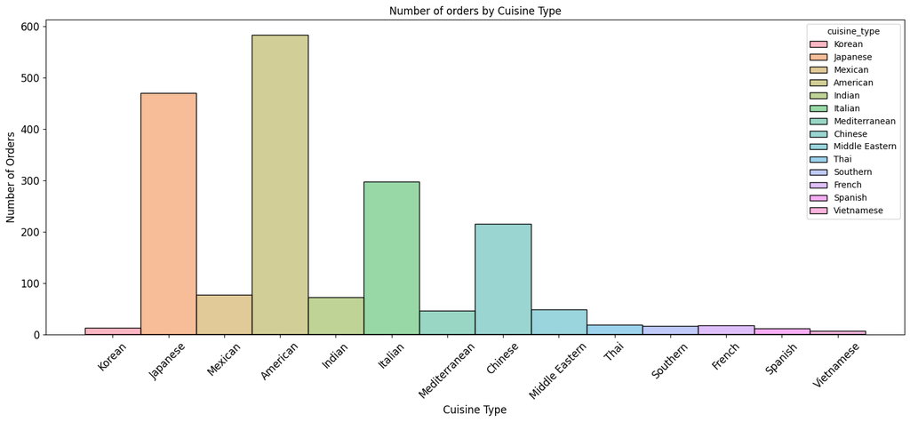

```python
#Number of orders by cuisine type histplot
#Create the histplot
plt.figure(figsize=(15, 7))
sns.histplot(data=df, x='cuisine_type',hue='cuisine_type')

#Customize the plot

plt.title('Number of orders by Cuisine Type')
plt.xlabel('Cuisine Type',fontsize=12)
plt.ylabel('Number of Orders',fontsize=12)
plt.xticks(rotation=45,fontsize=12)
plt.yticks(fontsize=12)
plt.tight_layout()
plt.show()
```

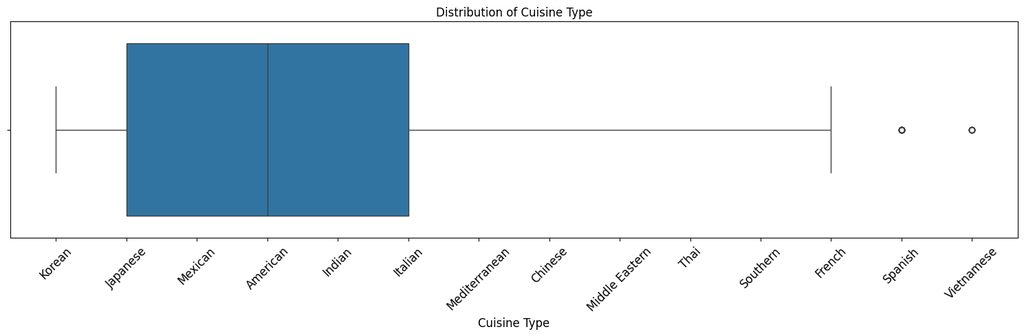

```python
#Distribution of Cuisine Type

#Create the histplot
plt.figure(figsize=(15,5))
sns.boxplot(data=df,x='cuisine_type')

#boxplot for Distribution of Cuisine Type
plt.title('Distribution of Cuisine Type')
plt.xlabel('Cuisine Type',fontsize=12)
plt.xticks(rotation=45,fontsize=12)
plt.yticks(fontsize=12)
plt.tight_layout()
plt.show()
```

Observations of cuisine_type

- There are 14 types of cuisine type: Korean, Japanese, Mexican, American, Indian, Italian,Mediterranean, Chinese, Middle Eastern, Thai, Southern,French, Spanish, Vietnamese
- Most of the orders go to American cuisine type (584) , followed by Japanese (470) and Italian (298)
- The cuisine type that dominates the boxplot is American with what could be outliers on Spanish and Vietnamese
- The boxplot is a right skewed distribution.

#### **Cost of Order**

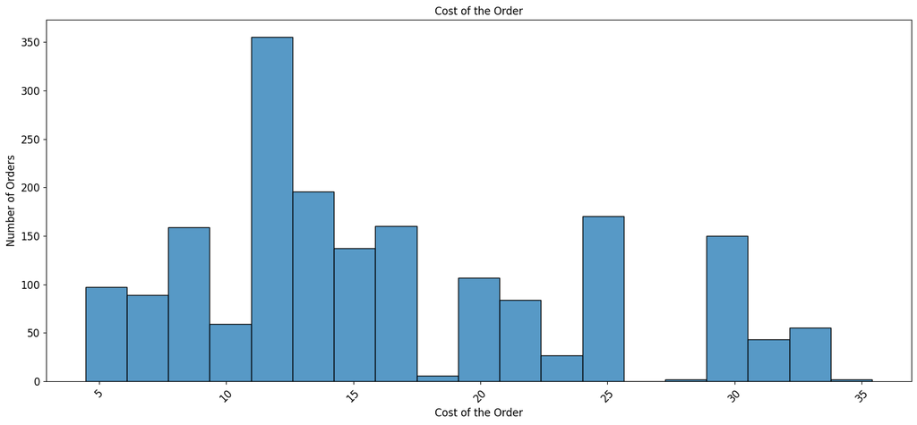

```python
#Cost of the orders by order
#Create the histplot
plt.figure(figsize=(15, 7))
sns.histplot(data=df, x='cost_of_the_order')

#Customize the plot

plt.title('Cost of the Order')
plt.xlabel('Cost of the Order',fontsize=12)
plt.ylabel('Number of Orders',fontsize=12)
plt.xticks(rotation=45,fontsize=12)
plt.yticks(fontsize=12)
plt.tight_layout()
plt.show()
```

```
Lower Whisker:  -3.246249999999998
Upper Whisker:  37.62375
IQR:  10.2175
Q1:  12.08
Q3:  22.2975
```

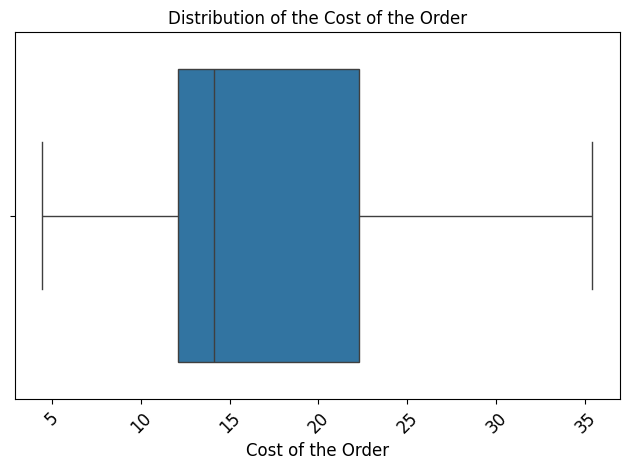

```python
# Find the Q1,Q3,IQR and Lower and upper whiskers of the boxplot below
Q1 = df['cost_of_the_order'].quantile(0.25)
Q3 = df['cost_of_the_order'].quantile(0.75)

IQR = Q3 - Q1                   #Inter Quantile Range (75th percentile - 25th percentile)

lower_whisker = Q1 - 1.5*IQR    #Finding lower and upper bounds for all values.
upper_whisker = Q3 + 1.5*IQR

#Print all the values to include in the analysis.
print("Lower Whisker: ",lower_whisker)
print("Upper Whisker: ",upper_whisker)
print("IQR: ",IQR)
print("Q1: ",Q1)
print("Q3: ",Q3)

#Create boxplot for the cost of the order
sns.boxplot(data=df,x='cost_of_the_order')
plt.title('Distribution of the Cost of the Order')
plt.xlabel('Cost of the Order',fontsize=12)
plt.xticks(rotation=45,fontsize=12)
plt.yticks(fontsize=12)
plt.tight_layout()
plt.show()
```

Observations of cost_of_the_order: The distribution is right skewed and there are not outliers with the following information:

- Lower Whisker: -3.246249999999998
- Upper Whisker: 37.62375
- IQR: 10.2175
- Q1: 12.08 (25% of the orders has a cost of 12.08 dollars)
- Q3: 22.2975 (75% of the orders has a cost of 22.2975 dollars)

#### **Day of the week**

```python
#How many unique values the day_of_the_week field has?
df['day_of_the_week'].unique()
```

```
array(['Weekend', 'Weekday'], dtype=object)
```

```python
#How many orders are placed over the weekend vs over the week?
df['day_of_the_week'].value_counts()
```

|  | day_of_the_week |
| --- | --- |
| Weekend | 1351 |
| Weekday | 547 |

**dtype:** int64

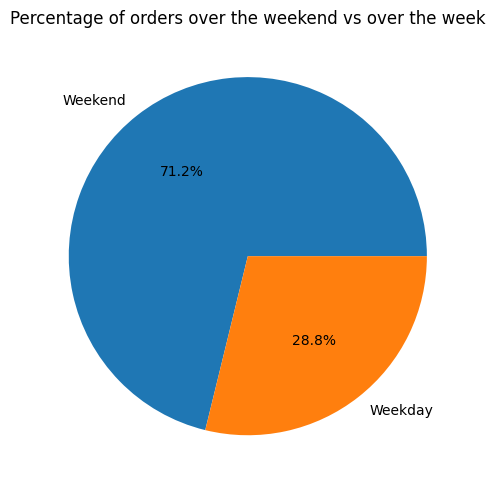

```python
#Create a pie to see what percentage of orders are placed over the weekend vs over the week.
plt.figure(figsize=(10,5))
plt.pie(df['day_of_the_week'].value_counts(),labels=df['day_of_the_week'].unique(),autopct='%1.1f%%')

#Customize the plot
plt.title('Percentage of orders over the weekend vs over the week')
plt.tight_layout()
plt.show()
```

Observations of day_of_the_week

- There are two unique values for day_of_the_week: Weekend and Weekday.
- Most of the orders are placed over the weekend.
- The number of orders placed over the weekend are more than double of the number of orders placed over a weekday.
- 71.2 % of the orders are placed over the weekend in comparison with only 28.8% of orders placed over the week.

#### **Rating**

```python
#What are the unique values for rating?
df['rating'].unique()
```

```
array(['Not given', '5', '3', '4'], dtype=object)
```

```python
#How many unique values we have for rating?
df['rating'].nunique()
```

```
4
```

```python
#What number of orders are rated in the different ratings?
df.groupby(['rating'])[['order_id']].count()
```

| rating | order_id |
| --- | --- |
| 3 | 188 |
| 4 | 386 |
| 5 | 588 |
| Not given | 736 |

```python
#What percentage of orders are in the different ratings?
df_percentage=df.groupby(['rating'])[['order_id']].count()/df.shape[0]*100
print(df_percentage)
```

```
            order_id
rating
3           9.905163
4          20.337197
5          30.979979
Not given  38.777661
```

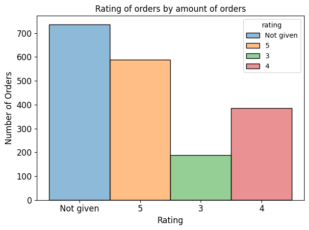

```python
#How the rating is divided in the amount of orders?
#Create the histplot

sns.histplot(data=df,x='rating',hue='rating')

#Customize the plot

plt.title('Rating of orders by amount of orders')
plt.xlabel('Rating',fontsize=12)
plt.ylabel('Number of Orders',fontsize=12)
plt.xticks(fontsize=12)
plt.yticks(fontsize=12)
plt.tight_layout()
plt.show()
```

Observations of rating

- There are 4 different ratings: Not given, 5, 3 and 4.
- Over 700 orders don't have a rating (rating=Not given), followed by less than 600 orders with rating 5. Less than 400 orders have rating 4 and only less than 200 have rating 3.
- 38.77 % of the orders are not rated in the dataset (rating=Not given), 30.97% of the orders have rating 5, 20.33% of the orders have rating 4 and only 9.90% of the orders have rating 3.

#### **Food preparation time**

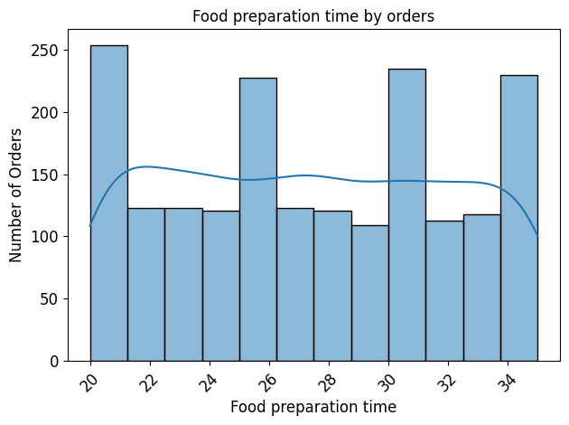

```python
# Food preparation time by amount of orders
sns.histplot(data=df,x='food_preparation_time',kde=True)


#Customize the plot
plt.title('Food preparation time by orders')
plt.xlabel('Food preparation time',fontsize=12)
plt.ylabel('Number of Orders',fontsize=12)
plt.xticks(rotation=45,fontsize=12)
plt.yticks(fontsize=12)
plt.tight_layout()
plt.show()
```

```
Lower Whisker:  11.0
Upper Whisker:  43.0
IQR:  8.0
Q1:  23.0
Q3:  31.0
```

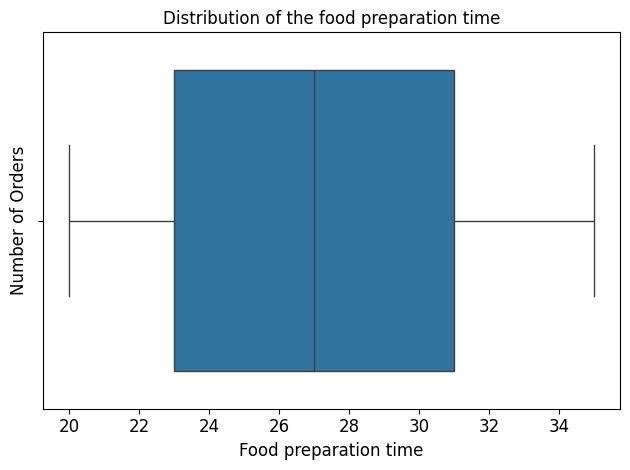

```python
# Find the Q1,Q3,IQR and Lower and upper whiskers of the boxplot below
Q1 = df['food_preparation_time'].quantile(0.25)
Q3 = df['food_preparation_time'].quantile(0.75)

IQR = Q3 - Q1                   #Inter Quantile Range (75th percentile - 25th percentile)

lower_whisker = Q1 - 1.5*IQR    #Finding lower and upper bounds for all values. All values outside these bounds are outliers
upper_whisker = Q3 + 1.5*IQR

print("Lower Whisker: ",lower_whisker)
print("Upper Whisker: ",upper_whisker)
print("IQR: ",IQR)
print("Q1: ",Q1)
print("Q3: ",Q3)

#Create the boxplot
sns.boxplot(data=df,x='food_preparation_time')

#Distribution of the food_preparation_time
plt.title('Distribution of the food preparation time')
plt.xlabel('Food preparation time',fontsize=12)
plt.ylabel('Number of Orders',fontsize=12)
plt.xticks(fontsize=12)
plt.yticks(fontsize=12)
plt.tight_layout()
plt.show()
```

Observations of food_preparation_time

- The food preparation time has 4 picks between 20-21 minutes, 25-26 minutes, 30-31 minutes and over 34 minutes.
- The distribution of food_preparation_time is fairly distributed with no outliers and with the following values :
- Lower Whisker: 11.0
- Upper Whisker: 43.0
- IQR: 8.0
- Q1: 23.0 (25% of the orders are prepared in 23 minutes)
- Q3: 31.0 (75% of the orders are prepared in 31 minutes)

#### **Delivery Time**

```python
#What is the delivery time for orders sorted by amount of orders delivered on each delivery time
df.groupby(['delivery_time'])[['order_id']].count().sort_values(by='order_id',ascending=False)
```

| delivery_time | order_id |
| --- | --- |
| 24 | 162 |
| 29 | 148 |
| 28 | 148 |
| 26 | 141 |
| 27 | 138 |
| 30 | 133 |
| 25 | 120 |
| 19 | 90 |
| 16 | 90 |
| 20 | 88 |
| 15 | 87 |
| 22 | 85 |
| 18 | 83 |
| 21 | 81 |
| 17 | 78 |
| 23 | 77 |
| 32 | 59 |
| 33 | 49 |
| 31 | 41 |

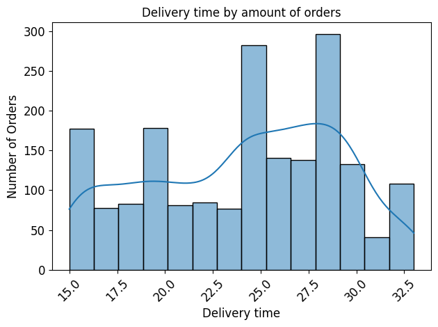

```python
#Create the histplot for delivery_time

sns.histplot(data=df,x='delivery_time',kde=True)

#Customize the plot

plt.title('Delivery time by amount of orders')
plt.xlabel('Delivery time',fontsize=12)
plt.ylabel('Number of Orders',fontsize=12)
plt.xticks(rotation=45,fontsize=12)
plt.yticks(fontsize=12)
plt.tight_layout()
plt.show()
```

```
Lower Whisker:  8.0
Upper Whisker:  40.0
IQR:  8.0
Q1:  20.0
Q3:  28.0
```

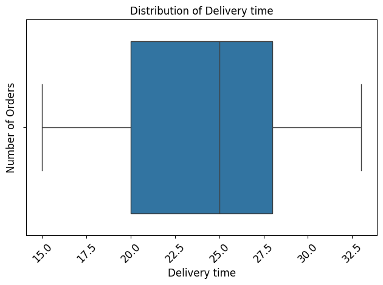

```python
# Find the Q1,Q3,IQR and Lower and upper whiskers of the boxplot below
Q1 = df['delivery_time'].quantile(0.25)
Q3 = df['delivery_time'].quantile(0.75)

IQR = Q3 - Q1                   #Inter Quantile Range (75th percentile - 25th percentile)

lower_whisker = Q1 - 1.5*IQR    #Finding lower and upper bounds for all values. All values outside these bounds are outliers
upper_whisker = Q3 + 1.5*IQR

print("Lower Whisker: ",lower_whisker)
print("Upper Whisker: ",upper_whisker)
print("IQR: ",IQR)
print("Q1: ",Q1)
print("Q3: ",Q3)

#Create the boxplot
sns.boxplot(data=df,x='delivery_time')

#Customize the plot

plt.title('Distribution of Delivery time')
plt.xlabel('Delivery time',fontsize=12)
plt.ylabel('Number of Orders',fontsize=12)
plt.xticks(rotation=45,fontsize=12)
plt.yticks(fontsize=12)
plt.tight_layout()
plt.show()
```

Observations of delivery_time:

- Most orders are delivered in 24 minutes with that range going from 20 to 28 minutes.
- The distribution is left skewed with no outliers.
- The values for the distribution are:
- Lower Whisker: 8.0
- Upper Whisker: 40.0
- IQR: 8.0
- Q1: 20.0 (25% of the orders are delivered in 20 minutes)
- Q3: 28.0 (75% of the orders are delivered in 28 minutes)

### **Question 7**: Which are the top 5 restaurants in terms of the number of orders received? [1 mark]

```python
# Write the code here
#Group by restaurant_name and get the count of orders, sort by order_id and restrict the dataframe to the first 5
df.groupby(['restaurant_name'])[['order_id']].count().sort_values(by='order_id',ascending=False).head(5)
```

| restaurant_name | order_id |
| --- | --- |
| Shake Shack | 219 |
| The Meatball Shop | 132 |
| Blue Ribbon Sushi | 119 |
| Blue Ribbon Fried Chicken | 96 |
| Parm | 68 |

#### Observations:

The top 5 restaurants are Shake Shack with 219 orders, The Meatball Shop with 132 orders , Blue Ribbon Sushi with 119 orders, Blue Ribbon Fried Chicken with 96 orders and lastly the Parm with 68 orders

### **Question 8**: Which is the most popular cuisine on weekends? [1 mark]

```python
# Write the code here
df_only_weekend=df[df['day_of_the_week']=='Weekend']
print("Orders over the weekend",df_only_weekend.shape[0])
df_only_weekend.groupby(['cuisine_type'])[['order_id']].count().sort_values(by='order_id',ascending=False).head(1)
```

```
Orders over the weekend 1351
```

| cuisine_type | order_id |
| --- | --- |
| American | 415 |

#### Observations:

American is the most popular cuisine on weekends with 415 orders out of 1351 total weekend orders.

### **Question 9**: What percentage of the orders cost more than 20 dollars? [2 marks]

```python
# Write the code here

# Get orders that cost more than 20 dollars
df_more_than_20_dollars = df[df['cost_of_the_order']>20].shape[0]
print("Amount of orders that cost more than 20 dollars:",df_more_than_20_dollars)

#Get the percentage of the orders that cost more than 20 dollars
percentage=(df_more_than_20_dollars/df.shape[0])*100

#Print the results
print("Percentage of orders that cost more than 20 dollars:",round(percentage,3),'%')
```

```
Amount of orders that cost more than 20 dollars: 555
Percentage of orders that cost more than 20 dollars: 29.241 %
```

#### Observations:

- The amount of orders that cost more than 20 dollars are 555, making them 29.241% of the total orders.

### **Question 10**: What is the mean order delivery time? [1 mark]

```python
# Write the code here
df['delivery_time'].mean()
```

```
24.161749209694417
```

#### Observations:

The mean of delivery time is 24.16 minutes.

### **Question 11:** The company has decided to give 20% discount vouchers to the top 3 most frequent customers. Find the IDs of these customers and the number of orders they placed. [1 mark]

```python
# Write the code here
df.groupby(['customer_id'])[['order_id']].count().sort_values(by='order_id',ascending=False).head(3)
```

| customer_id | order_id |
| --- | --- |
| 52832 | 13 |
| 47440 | 10 |
| 83287 | 9 |

#### Observations:

The following customer's id have placed the most orders: 52832 (13 orders), 47440 (10 orders), 83287 (9 orders)

### **Question 12**: Perform a multivariate analysis to explore relationships between the important variables in the dataset. (It is a good idea to explore relations between numerical variables as well as relations between numerical and categorical variables) [10 marks]

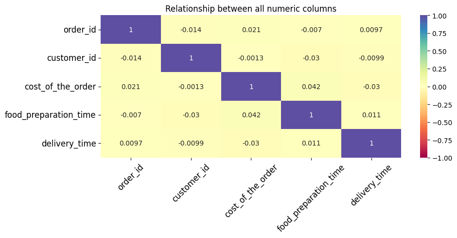

```python
# Write the code here

plt.figure(figsize=(10,5))
sns.heatmap(df.corr(numeric_only = True),annot=True,cmap='Spectral',vmin=-1,vmax=1)

#Customize the heatmap.
plt.title('Relationship between all numeric columns')
plt.xticks(rotation=45,fontsize=12)
plt.yticks(fontsize=12)
plt.tight_layout()
plt.show()
```

There is not an strong relationship between the numeric values of the dataset. We will explore now the relationship between categorical and numerical values that could be related.

##### Observations of cuisine_type and cost_of_the_order

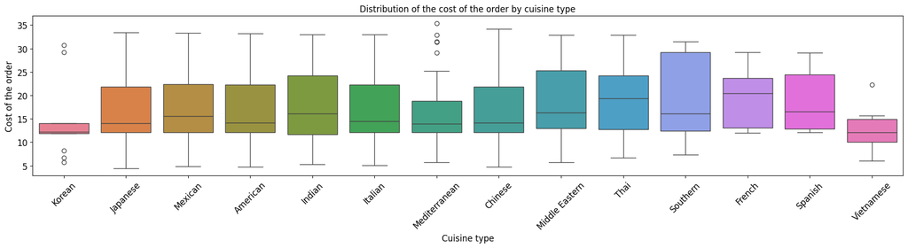

```python
#cuisine_type	and cost_of_the_order

#Create the boxplot
plt.figure(figsize=(18,5))
sns.boxplot(data = df , x = 'cuisine_type' , y = 'cost_of_the_order',hue='cuisine_type');

#Customize the boxplot
plt.title('Distribution of the cost of the order by cuisine type')
plt.xlabel('Cuisine type',fontsize=12)
plt.ylabel('Cost of the order',fontsize=12)
plt.xticks(rotation=45,fontsize=12)
plt.yticks(fontsize=12)
plt.tight_layout()
plt.show()
```

##### Observations cuisine_type and food_preparation_time

- The median preparation time for Korean and Vietnamease food is less than all the other median food preparation times for the rest of the cuisine types.

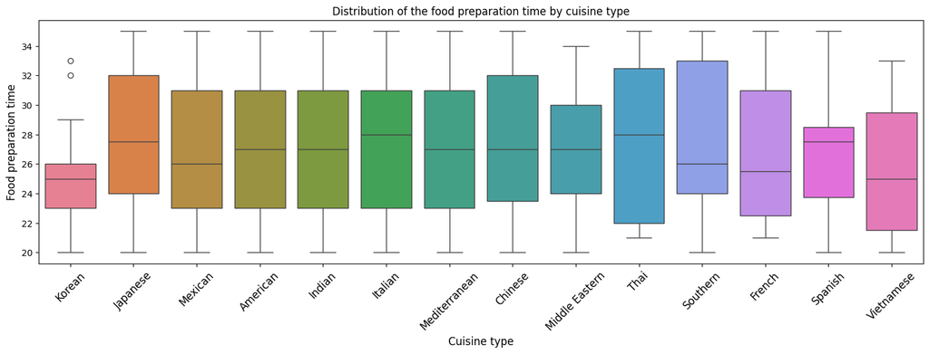

```python
#cuisine type and food_preparation_time
plt.figure(figsize=(18,5))
sns.boxplot(data = df , x = 'cuisine_type' , y = 'food_preparation_time',hue='cuisine_type');

#Customize the plot
plt.title('Distribution of the food preparation time by cuisine type')
plt.xlabel('Cuisine type',fontsize=12)
plt.ylabel('Food preparation time',fontsize=12)
plt.xticks(rotation=45,fontsize=12)
plt.show()
```

##### Observations of cuisine_type and delivery_time

There is not an strong relationship between cuisine_type and delivery_time given on average for most of the cuisine types the delivery time is between 25 and 27.5 minutes.

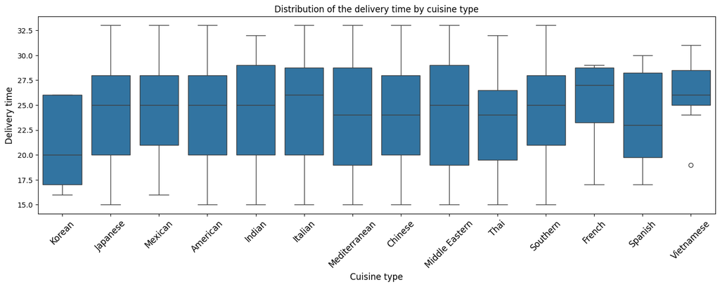

```python
#cuisine type and delivery_time
plt.figure(figsize=(17,5))

sns.boxplot(data = df , x = 'cuisine_type' , y = 'delivery_time');

#Customize the plot
plt.title('Distribution of the delivery time by cuisine type')
plt.xlabel('Cuisine type',fontsize=12)
plt.ylabel('Delivery time',fontsize=12)
plt.xticks(rotation=45,fontsize=12)
plt.show()
```

##### Observations of day of the week and cost of the order

- There is barely any difference between the two boxplots for day of the week and cost of the order. Meaning the cost of the order does not change depending on the day of the week.

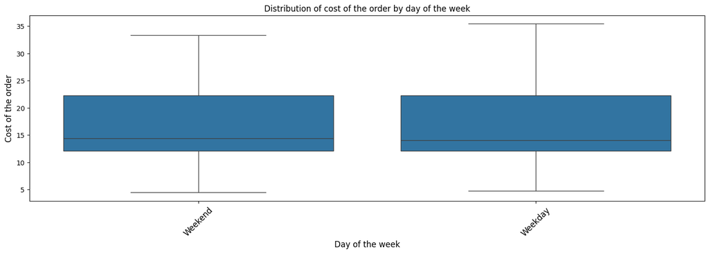

```python
#day of the week and cost of the order
plt.figure(figsize=(18,5))

sns.boxplot(data = df , x = 'day_of_the_week' , y = 'cost_of_the_order');

#Customize the plot
plt.title('Distribution of cost of the order by day of the week')
plt.xlabel('Day of the week',fontsize=12)
plt.ylabel('Cost of the order',fontsize=12)
plt.xticks(rotation=45,fontsize=12)
plt.show()
```

##### Observations of day of the week and food_preparation_time

It looks like the food preparation time does not relate to the day of the week. Meaning the time to prepare an order is not influenced by the day of the week the order is placed

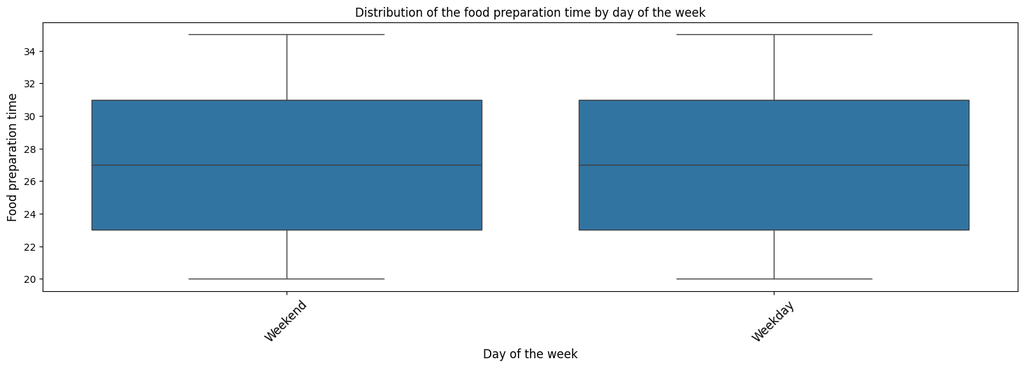

```python
#day of the week and food_preparation_time
plt.figure(figsize=(18,5))

sns.boxplot(data = df , x = 'day_of_the_week' , y = 'food_preparation_time');

#Customize the plot
plt.title('Distribution of the food preparation time by day of the week')
plt.xlabel('Day of the week',fontsize=12)
plt.ylabel('Food preparation time',fontsize=12)
plt.xticks(rotation=45,fontsize=12)
plt.show()
```

##### Observations day_of_the_week and delivery_time

- The delivery time over the week is bigger than the delivery time over the weekend. Both distribution are fairly distributed with the median of orders for weekdays over 27.5 minutes, the median for weekends are far less, below 22.5 minutes.
- Given the delivery time is more over the week than the weekend we will analyse later if the rating is tight to the delivery time in any way.

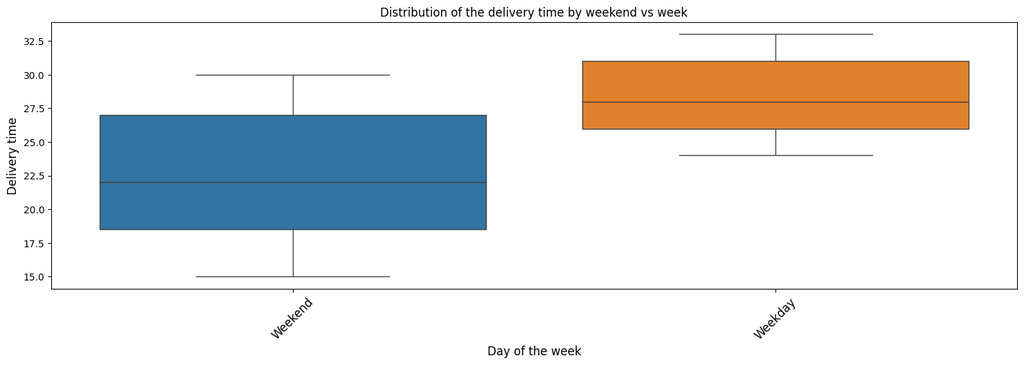

```python
#day of the week and delivery_time
plt.figure(figsize=(18,5))
sns.boxplot(data =df , x = 'day_of_the_week' , y = 'delivery_time',hue='day_of_the_week');

#Customize the plot
plt.title('Distribution of the delivery time by weekend vs week')
plt.xlabel('Day of the week',fontsize=12)
plt.ylabel('Delivery time',fontsize=12)
plt.xticks(rotation=45,fontsize=12)
plt.show()
```

##### Observations rating and cost of the order

It looks like rating **could** be related to the cost of order. For the highest average cost of the order, the ratings are 5 and 4 having orders with the cheapest cost with rating Not given or 3.

```python
#Get the mean of cost_of_order by rating
df.groupby(['rating'])[['cost_of_the_order']].mean()
```

| rating | cost_of_the_order |
| --- | --- |
| 3 | 16.223351 |
| 4 | 16.710337 |
| 5 | 16.965697 |
| Not given | 16.085340 |

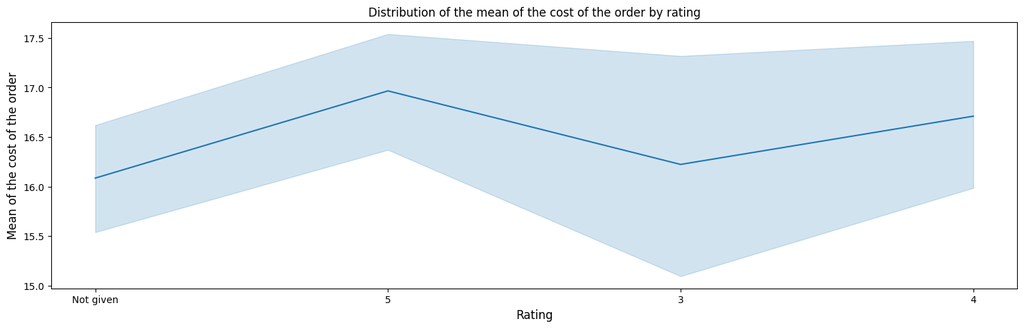

```python
#rating vs mean of the cost of the order
plt.figure(figsize=(18,5))
sns.lineplot(data = df , x = 'rating' , y = 'cost_of_the_order',estimator='mean');

#Customize the plot
plt.title('Distribution of the mean of the cost of the order by rating')
plt.xlabel('Rating',fontsize=12)
plt.ylabel('Mean of the cost of the order',fontsize=12)
plt.show()
```

##### Observations rating and food_preparation_time

The food preparation time does not impact the rating given the average preparation time for all ratings is very similar.

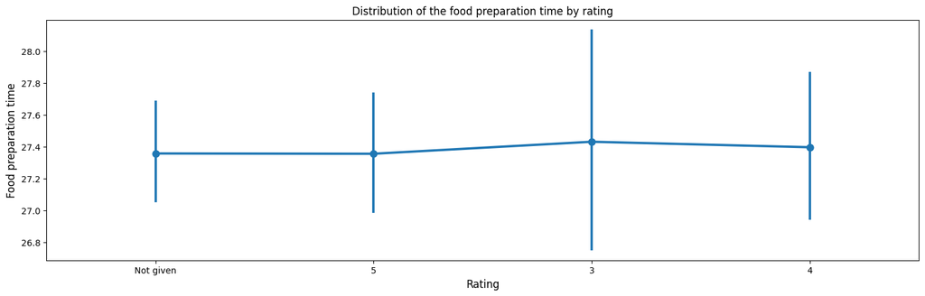

```python
#rating vs food_preparation_time
plt.figure(figsize=(18,5))
sns.pointplot(data = df , x = 'rating' , y = 'food_preparation_time');
#Customize the plot
plt.title('Distribution of the food preparation time by rating')
plt.xlabel('Rating',fontsize=12)
plt.ylabel('Food preparation time',fontsize=12)
plt.show()
```

##### Observations rating and delivery_time

There is no an strong relationship between delivery_time and rating. Rating 3 which is neutral has the longest average delivery time, therefore we can not assume that the delivery time is tightly strongly to the rating.

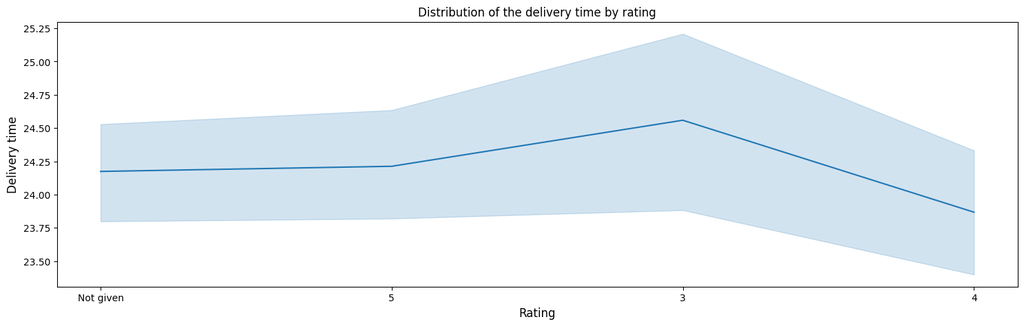

```python
#rating vs delivery time
plt.figure(figsize=(18,5))
sns.lineplot(data = df , x = 'rating' , y = 'delivery_time');
#Customize the plot
plt.title('Distribution of the delivery time by rating')
plt.xlabel('Rating',fontsize=12)
plt.ylabel('Delivery time',fontsize=12)
plt.show()
```

### **Question 13:** The company wants to provide a promotional offer in the advertisement of the restaurants. The condition to get the offer is that the restaurants must have a rating count of more than 50 and the average rating should be greater than 4. Find the restaurants fulfilling the criteria to get the promotional offer. [3 marks]

```python
# Write the code here
df_restaurants_with_rating=df[df['rating']!='Not given'].copy()
#convert the rating to int.
df_restaurants_with_rating['rating']=df_restaurants_with_rating['rating'].astype('int')

#count and mean of restaurants with rating
df_offer=df_restaurants_with_rating.groupby('restaurant_name')['rating'].agg(['count', 'mean']).sort_values(by=['count','mean'],ascending=False).reset_index()

#get the restaurants that have more than 50 reviews and an average of rating greater than 4
df_offer=df_offer[(df_offer['count']>50) & (df_offer['mean']>4)]
df_offer
```

|  | restaurant_name | count | mean |
| --- | --- | --- | --- |
| 0 | Shake Shack | 133 | 4.278195 |
| 1 | The Meatball Shop | 84 | 4.511905 |
| 2 | Blue Ribbon Sushi | 73 | 4.219178 |
| 3 | Blue Ribbon Fried Chicken | 64 | 4.328125 |

#### Observations:

The following restaurants have more than 50 reviews with an average rating greater than 4: Shake Shack with 133 reviews and 4.27 average rating, The Meatball Shop with 84 reviews and 4.51 average rating, Blue Ribbon Sushi with 73 reviews and 4.21 average rating and Blue Ribbon Fried Chicken witn 64 reviews and 4.32 average rating.

### **Question 14:** The company charges the restaurant 25% on the orders having cost greater than 20 dollars and 15% on the orders having cost greater than 5 dollars. Find the net revenue generated by the company across all orders. [3 marks]

```python
# Write the code here

def revenue(cost):
  if cost > 20:
    return cost * 0.25
  elif cost > 5:
    return cost * 0.15
  else:
    return 0

df_with_revenue=df.copy()
df_with_revenue['revenue']=df_with_revenue['cost_of_the_order'].apply(revenue)
df_with_revenue['revenue'].sum()
```

```
6166.303
```

#### Observations:

The total revenue based only on the surcharge for the whole dataset is 6166.303 dollars

### **Question 15:** The company wants to analyze the total time required to deliver the food. What percentage of orders take more than 60 minutes to get delivered from the time the order is placed? (The food has to be prepared and then delivered.) [2 marks]

```python
# Write the code here
#copy the original dataframe
df_total_to_deliver=df.copy()

#create a new column in the dataset named total_time_to_deliver and assign the summarization of food_preparation_time and delivery_time

df_total_to_deliver['total_time_to_deliver']=df_total_to_deliver['food_preparation_time']+df_total_to_deliver['delivery_time']

#get the percentage of the total_time_to_deliver for orders that take more than  60 minutes

percentage=df_total_to_deliver[df_total_to_deliver['total_time_to_deliver']>60].value_counts().sum()/df_total_to_deliver.shape[0]*100

#Print the results
print("Percentage of orders that take more than 60 minutes to get delivered since the time the order is placed:",round(percentage,2),'%')
```

```
Percentage of orders that take more than 60 minutes to get delivered since the time the order is placed: 10.54 %
```

#### Observations:

The percentage of orders that take more than 60 minutes to get delivered since the time of the order is placed is 10.54%

### **Question 16:** The company wants to analyze the delivery time of the orders on weekdays and weekends. How does the mean delivery time vary during weekdays and weekends? [2 marks]

```python
# Write the code here

df.groupby(['day_of_the_week'])[['delivery_time']].mean().round(0).astype(int)
```

| day_of_the_week | delivery_time |
| --- | --- |
| Weekday | 28 |
| Weekend | 22 |

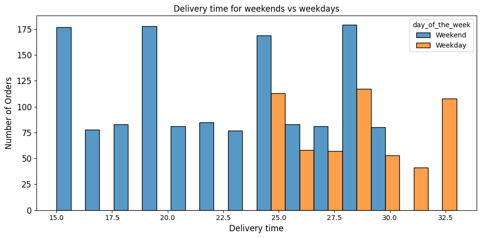

```python
#Create an histplot for delivery_time.
plt.figure(figsize=(10,5))
sns.histplot(data=df, x='delivery_time', hue='day_of_the_week',  multiple='dodge');

#Customize the heatmap.
plt.title('Delivery time for weekends vs weekdays')
plt.xlabel('Delivery time',fontsize=12)
plt.ylabel('Number of Orders',fontsize=12)
plt.yticks(fontsize=12)
plt.tight_layout()
plt.show()
```

#### Observations:

The mean delivery time on week days is 28 minutes and the mean delivery time on weekends is 22 minutes. The delivery time is longer on week days compared with weekends given there are no bars before 24 minutes for weekday in the graphic above.

### Conclusion and Recommendations

### **Question 17:** What are your conclusions from the analysis? What recommendations would you like to share to help improve the business? (You can use cuisine type and feedback ratings to drive your business recommendations.) [6 marks]

### Conclusions

I analyzed a dataset of nearly 2000 orders and their reviews for restaurants in New York city.

I have been able to conclude that:

- The dataset contains the following fields: order_id, customer_id, restaurant_name,cuisine_type,cost_of_the_order,day_of_the_week, rating,food_preparation_time, delivery_time.

We have 4 fields that are object: restaurant_name, cuisine_type, day_of_the_week and rating. We have 4 fields that are integer order_id, customer_id, food_preparation_time and delivery_time. We have 1 field that is a float type: cost_of_the_order -There are no null/missing/duplicated values in the dataset. -The amount of orders that are not rated is 736, 529 over the weekend and 207 over the week.

- The top 5 restaurants in terms of number of orders are: Shake Shack with 219 orders, The Meatball Shop with 132 orders , Blue Ribbon Sushi with 119 orders, Blue Ribbon Fried Chicken with 96 orders and lastly the Parm with 68 orders.
- American is the most popular cuisine on weekends with 415 orders out of 1351 total weekend orders.
- The amount of orders that cost more than 20 dollars are 555, making them 29.241% of the total orders.
- The mean of delivery time is 24.16 minutes.
- The following customer's id have placed the most orders: 52832 (13 orders), 47440 (10 orders), 83287 (9 orders) and should received the 20% discount vouchers.
- The following restaurants have more than 50 reviews with an average rating greater than 4 and should get the advertising in the FoodHub application: Shake Shack with 133 reviews and 4.27 average rating, The Meatball Shop with 84 reviews and 4.51 average rating, Blue Ribbon Sushi with 73 reviews and 4.21 average rating and Blue Ribbon Fried Chicken witn 64 reviews and 4.32 average rating.
- The total revenue based only on the surcharge for the whole dataset is 6166.303 dollars
- The percentage of orders that take more than 60 minutes to get delivered since the time the order is placed is 10.54%
- The mean delivery time on week days is 28 minutes and the mean delivery time on weekends is 22 minutes. The delivery time is longer on week days compared with weekends.
- There are 1200 different customers in the dataset.
- There are 178 restaurants in the dataset.
- We have 14 different cuisine types. The one with most orders are American and the one with the less orders are Vietnamese.

#### Observations

- The number of orders placed over the weekend are more than double of the number of orders placed over a weekday. 71.2 % of the orders are placed over the weekend in comparison with only 28.8% of orders placed over the week.
- Even though there are more orders over the weekend, the delivery time is higher over the week.

#### Further Analysis that can be done

- Check some restaurant names with special characters and find out the real name so it can be replaced.

### Recommendations:

- 38% of reviews have a rating of "Not Given". A survey could be sent to a subset of the customers that have not rated orders to see the reason behind it and find ways to implement a more engaging rating system.
- American is the most popular cuisine on weekends therefore FoodHub could add special offers for the customers buying from a restaurant with American as cuisine type.
- Most of the orders are placed over the weekend with better delivery time than weekdays. Although this could be due to traffic, closure of streets for construction, I would recommend to review the amount of drivers available and maybe place them around the restaurants with the most orders during the week to minimize delivery time.
- 10.54% of orders take more than an hour to get delivered. This can affect the ratings on the FoodHub application and therefore lose clients in the future. I recommend to look into those orders, check with the restaurants involved and see what can be done to lower the total time.